# Assignment1 : Medical Databases

### Answer 16:

I am thing the model should work well

```r
#Now we can train our XGBoost model
xgb.grid <- expand.grid(eta=c(0.05),
                       max_depth=c(4),colsample_bytree=1,
                       subsample=1, nrounds=500, gamma=0, min_child_weight=5)

xgb.model <- train(NoShow ~ .,data=train, method="xgbTree",metric="ROC",
                  tuneGrid=xgb.grid, trControl=fit.control)

xgb.pred <- predict(xgb.model, newdata=test)
xgb.probs <- predict(xgb.model, newdata=test, type="prob")
```

```r
test <- test %>% mutate(NoShow.numerical = ifelse(NoShow=="Yes",1,0))
confusionMatrix(xgb.pred, test$NoShow, positive="Yes")
```

```
## Confusion Matrix and Statistics
##
##           Reference
## Prediction    No   Yes
##        No  11044   487
##        Yes    10    30
##
##                Accuracy : 0.957
##                  95% CI : (0.9532, 0.9607)
##     No Information Rate : 0.9553
##     P-Value [Acc > NIR] : 0.1905
##
##                   Kappa : 0.102
##
##  Mcnemar's Test P-Value : <2e-16
##
##             Sensitivity : 0.058027
##             Specificity : 0.999095
##          Pos Pred Value : 0.750000
##          Neg Pred Value : 0.957766
##              Prevalence : 0.044681
##          Detection Rate : 0.002593
##    Detection Prevalence : 0.003457
##       Balanced Accuracy : 0.528561
##
##        'Positive' Class : Yes
##
```

```r
paste("XGBoost Area under ROC Curve: ", round(auc(test$NoShow.numerical, xgb.probs[,2]),3), sep="")
```

```
## [1] "XGBoost Area under ROC Curve: 0.706"
```

This isn’t an unreasonable performance, but let’s look a bit more carefully at the correct and incorrect predictions,

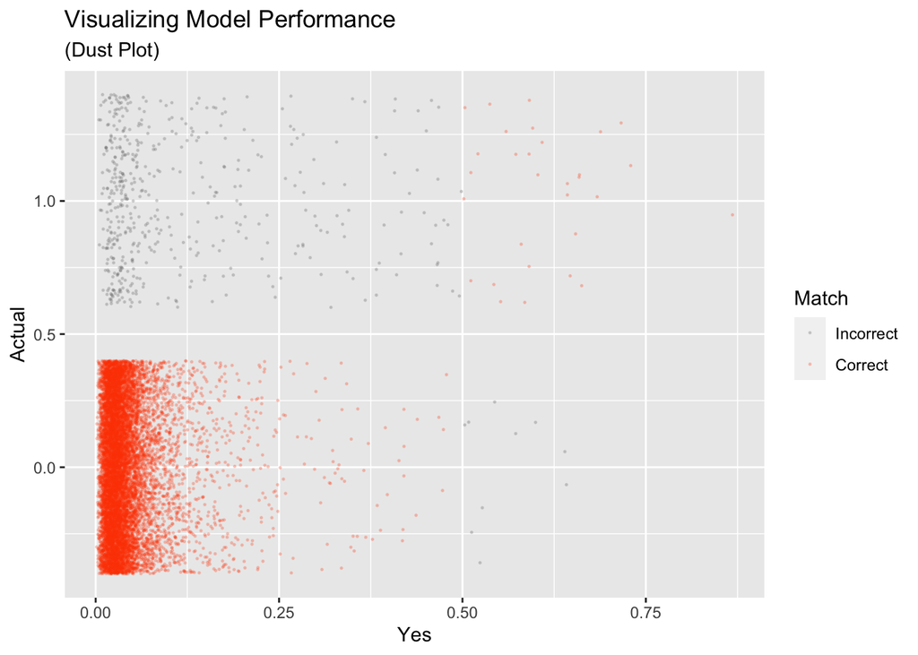

```r
xgb.probs$Actual = test$NoShow.numerical
xgb.probs$ActualClass = test$NoShow
xgb.probs$PredictedClass = xgb.pred
xgb.probs$Match = ifelse(xgb.probs$ActualClass == xgb.probs$PredictedClass,
                         "Correct","Incorrect")
# [4.8] Plot Accuracy
xgb.probs$Match = factor(xgb.probs$Match,levels=c("Incorrect","Correct"))
ggplot(xgb.probs,aes(x=Yes,y=Actual,color=Match))+
  geom_jitter(alpha=0.2,size=0.25)+
  scale_color_manual(values=c("grey40","orangered"))+
  ggtitle("Visualizing Model Performance", "(Dust Plot)")
```

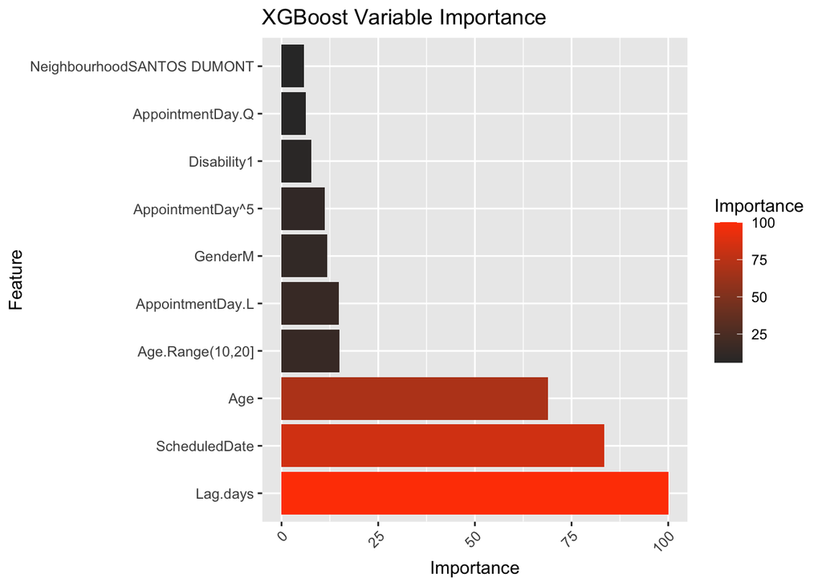

```r
#Finally, let’s close it off with the variable importance of our model:
results = data.frame(Feature = rownames(varImp(xgb.model)$importance)[1:10],
                     Importance = varImp(xgb.model)$importance[1:10,])
results <- results[order(results$Importance, decreasing = TRUE), ]
results$Feature = factor(results$Feature,levels=results$Feature)


# [4.10] Plot Variable Importance
ggplot(results, aes(x=Feature, y=Importance,fill=Importance))+
  geom_bar(stat="identity")+
  scale_fill_gradient(low="grey20",high="orangered")+
  ggtitle("XGBoost Variable Importance")+
  theme(axis.text.x = element_text(angle = 45, hjust = 1))+
  coord_flip()  # Flip coordinates to put variable names on the vertical axis
```

### Q17 Using the caret package fit and evaluate 1 other ML model on this data.

### Answer 17:

We can use **Random Forest** model form **caret** package.

```r
# Define the grid for hyperparameter tuning
rf.grid <- expand.grid(mtry = c(2, 3, 4))

# Train the Random Forest model
rf.model <- train(NoShow ~ ., data=train, method="rf", metric="ROC",
                  tuneGrid=rf.grid, trControl=fit.control)

# Make predictions
rf.pred <- predict(rf.model, newdata=test)
rf.probs <- predict(rf.model, newdata=test, type="prob")
```

Evaluate the Random Forest Model

```r
# Add numerical NoShow column for ROC calculation
test <- test %>% mutate(NoShow.numerical = ifelse(NoShow == "Yes", 1, 0))

# Confusion Matrix
confusionMatrix(rf.pred, test$NoShow, positive="Yes")
```

```
## Confusion Matrix and Statistics
##
##           Reference
## Prediction    No   Yes
##        No  11054   517
##        Yes     0     0
##
##                Accuracy : 0.9553
##                  95% CI : (0.9514, 0.959)
##     No Information Rate : 0.9553
##     P-Value [Acc > NIR] : 0.5117
##
##                   Kappa : 0
##
##  Mcnemar's Test P-Value : <2e-16
##
##             Sensitivity : 0.00000
##             Specificity : 1.00000
##          Pos Pred Value :     NaN
##          Neg Pred Value : 0.95532
##              Prevalence : 0.04468
##          Detection Rate : 0.00000
##    Detection Prevalence : 0.00000
##       Balanced Accuracy : 0.50000
##
##        'Positive' Class : Yes
##
```

```r
# Calculate Area Under the ROC Curve (AUC)
paste("Random Forest Area under ROC Curve: ", round(auc(test$NoShow.numerical, rf.probs[,2]), 3), sep="")
```

```
## [1] "Random Forest Area under ROC Curve: 0.708"
```

Visualize Model Performance

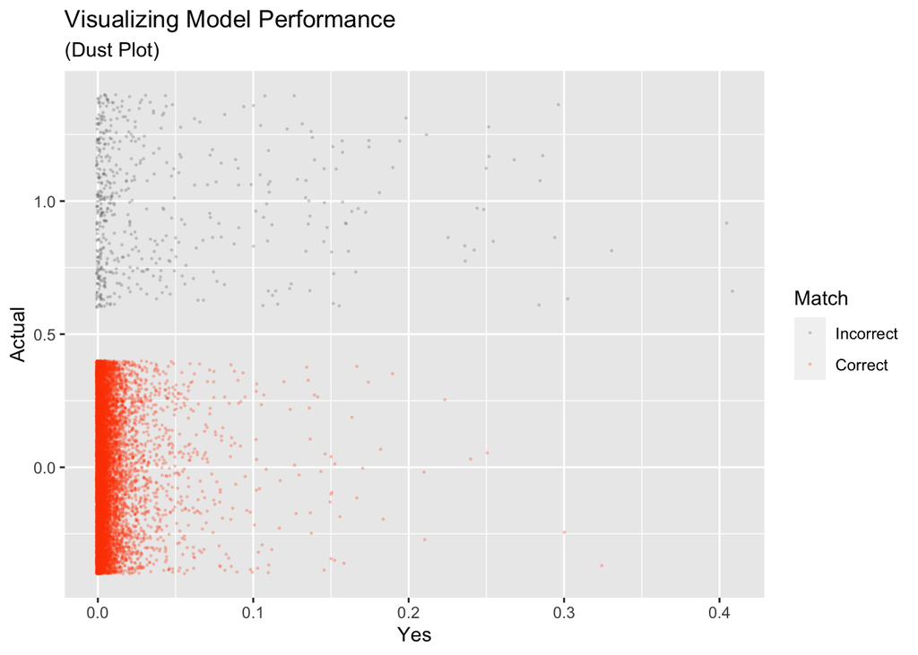

```r
# Prepare data for visualization
rf.probs$Actual <- test$NoShow.numerical
rf.probs$ActualClass <- test$NoShow
rf.probs$PredictedClass <- rf.pred
rf.probs$Match <- ifelse(rf.probs$ActualClass == rf.probs$PredictedClass, "Correct", "Incorrect")

# Plot Accuracy
rf.probs$Match <- factor(rf.probs$Match, levels=c("Incorrect", "Correct"))
ggplot(rf.probs, aes(x=Yes, y=Actual, color=Match)) +
  geom_jitter(alpha=0.2, size=0.25) +
  scale_color_manual(values=c("grey40", "orangered")) +
  ggtitle("Visualizing Model Performance", "(Dust Plot)")
```

Variable Importance

```r
# Get variable importance for Random Forest
rf.importance <- varImp(rf.model)
```

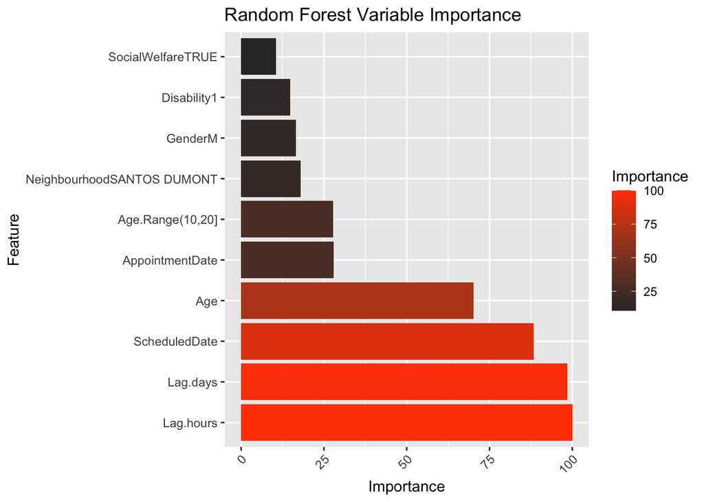

```r
# Prepare data for plotting, ensuring all features are included
rf.results <- data.frame(Feature = rownames(rf.importance$importance),
                         Importance = rf.importance$importance[,1])
# Order the features by importance
rf.results <- rf.results[order(rf.results$Importance, decreasing = TRUE), ]

# Keep only the top 10 features
rf.results <- rf.results[1:10, ]
rf.results$Feature <- factor(rf.results$Feature, levels = rf.results$Feature)

# Plot Variable Importance for Random Forest
ggplot(rf.results, aes(x=Feature, y=Importance, fill=Importance)) +
  geom_bar(stat="identity") +
  scale_fill_gradient(low="grey20", high="orangered") +
  ggtitle("Random Forest Variable Importance") +
  theme(axis.text.x = element_text(angle = 45, hjust = 1)) +
  coord_flip()  # Flip coordinates to put variable names on the vertical axis
```

### Q18 Based on everything, do you think we can trust analyses based on this dataset? Explain your reasoning.

### Answer 18:

Based on the analysis and the dust plot, it appears that your both Random Forest (RF) model and XGboost model perform better at predicting the “0” class (patients who show up for their appointments) compared to the “1” class (patients who do not show up).

There is a dense cluster of red points in the bottom-left corner, indicating that the model correctly predicts many of the patients who show up (low predicted probability for “Yes” when Actual is 0). This suggests that the model is effective at identifying patients who will attend their appointments.

However, there are fewer red points in the top-right corner, which indicates that the model correctly predicts fewer no-shows (high predicted probability for “Yes” when Actual is 1). This suggests that the models struggles more with correctly identifying patients who will not show up for their appointments.

Since the problem true for both of the models we can assume that the problem is with the data set, whcih have limited capacity to predict the no show.